# Skills for Analysis Assignment 5

GSD SES 5394

Spring 2023

# Overview

This page presents an approach to calculating accessibility for Analysis Assignment 5, using either a cumulative opportunity measure or a gravity- based measure.

The examples here use the following packages:

```r
library(readxl)
library(here)
library(tidyverse)
library(knitr)
library(sf)
library(ggthemes)
library(ggspatial)
```

# Step 1: Importing skims to R

Once you’ve finished your transit skims and road skims in TransCAD, you can open them in R and combine them into a single dataframe, with columns representing origins and destinations, and a column for each matrix.

First, you can read in the matices from their Excel files.

```r
IVTT <- here("Examples",
             "rochester",
             "transit-skim.xlsx") %>%
  read_xlsx(sheet = "In-Vehicle Time")

transit_time <- here("Examples",
             "rochester",
             "transit-skim.xlsx") %>%
  read_xlsx(sheet = "Total Time")

transfers <- here("Examples",
             "rochester",
             "transit-skim.xlsx") %>%
  read_xlsx(sheet = "Number of Transfers")

car_time <- here("Examples",
             "rochester",
             "road-skim.xlsx") %>%
  read_xlsx(sheet = "TravelTime")
```

Then you can pivot each matrix to have a column indicating the origin and a column indicating the destination.

```r
transfers_long <- transfers %>%
  pivot_longer(cols = -GEOID) %>%
  mutate(value = as.numeric(value)) %>%
  # Careful with leading zeros if your state is early in the alphabet
  mutate(GEOID = as.character(GEOID)) %>%
  rename(from_GEOID = GEOID,
         to_GEOID = name,
         n_transfers = value)

IVTT_long <- IVTT %>%
  pivot_longer(cols = -GEOID) %>%
  mutate(value = as.numeric(value)) %>%
  mutate(GEOID = as.character(GEOID)) %>%
  rename(from_GEOID = GEOID,
         to_GEOID = name,
         IVTT = value)

transit_time_long <- transit_time %>%
  pivot_longer(cols = -GEOID) %>%
  mutate(value = as.numeric(value)) %>%
  mutate(GEOID = as.character(GEOID)) %>%
  rename(from_GEOID = GEOID,
         to_GEOID = name,
         total_time = value)

car_long <- car_time %>%
  pivot_longer(cols = -GEOID) %>%
  mutate(value = as.numeric(value)) %>%
  mutate(GEOID = as.character(GEOID)) %>%
  rename(from_GEOID = GEOID,
         to_GEOID = name,
         car_time = value)

full_skim <- full_join(IVTT_long, transfers_long) %>%
  full_join(transit_time_long) %>%
  full_join(car_long) %>%
  filter(from_GEOID != to_GEOID)
```

Here are the first few rows of the resulting dataframe:

```r
head(full_skim) %>%
  kable()
```

| from_GEOID | to_GEOID | IVTT | n_transfers | total_time | car_time |
| --- | --- | --- | --- | --- | --- |
| 36051030300 | 36051030400 | 21.5 | 0 | 58.3 | 16 |
| 36051030300 | 36051030500 | 23.0 | 0 | 63.8 | 16 |
| 36051030300 | 36051030900 | 50.1 | 0 | 67.6 | 25 |
| 36051030300 | 36051031400 | NA | NA | NA | 37 |
| 36051030300 | 36055000200 | NA | NA | NA | 32 |
| 36051030300 | 36055000700 | NA | NA | NA | 32 |

# Step 2 (Optional): Calculate perceived travel time

In general, people are more bothered by out-of-vehicle time than in-vehicle time, and models commonly weight out-of-vehicle time to be two- to three-times as bad as in-vehicle time.

You can add an adjustment factor like this if you want to.

```r
full_skim <- full_skim %>%
  mutate(OVTT = total_time - IVTT) %>%
  mutate(percieved_time = (IVTT + 2.5 * OVTT))
```

# Step 2: Add employment data

We’ll focus this analysis on access to jobs (remind me to revisit this when we’ve done the trip generation step). Load the data you assembled for A02.

```r
tracts <- here("Examples",
                   "rochester",
                   "rochester_tracts.geojson") %>%
  st_read()

employment_data <- tracts %>%
  st_drop_geometry() %>%
  select(GEOID, total_emp) %>%
  rename(to_GEOID = GEOID)
```

Now I can add the number of jobs at each destination to my skim dataframe.

```r
accessibility_df <- full_skim %>%
  left_join(employment_data)
```

# Step 3: Define some decay functions

Let’s define some decay functions as functions (good practice for writing functions in R).

You don’t need to use all of these. Choose one. Here is a tool you can use to visualize each of these functions:

https://urban-stack.shinyapps.io/access-decay/

Does it matter which decay function you choose? [Santana Palacios and El-geneidy 2022](https://findingspress.org/article/32444-cumulative-versus-gravity-based-accessibility-measures-which-one-to-use) would argue that it does not.

```r
step_function <- function(travel_time, cutoff) {
   ifelse(travel_time > cutoff, 0, 1)
}

exponential_function <- function(travel_time, halflife) {
  lambda = log(2) / halflife
  exp(travel_time * -1 * lambda)
}

exponential_function <- function(travel_time, halflife) {
  lambda = log(2) / halflife
  exp(travel_time * -1 * lambda)
}

logistic_function <- function(travel_time, inflection, stdev) {
  1/(1+exp((travel_time - inflection) / stdev))
}

linear_function <-  function(travel_time, midpoint, width) {
  case_when(travel_time <= midpoint - (width / 2) ~ 1,
            travel_time >= midpoint + (width / 2) ~ 0,
            TRUE ~ 0.5 - ((travel_time - midpoint) / width))
}
```

# Step 4: Weight jobs for each origin-destination pair

You can use one of the decay functions you’ve defined to calculate a weight for the jobs at in each zone. You’ll need to choose parameters for the decay function you choose.

```r
accessibility_df <- accessibility_df %>%
  mutate(weight_car = logistic_function(car_time, 30, 10),
         weight_transit = logistic_function(percieved_time, 30, 10))
```

Then you can multiply the number of jobs by its weight.

```r
accessibility_df <- accessibility_df %>%
  mutate(transit_jobs = total_emp * weight_transit,
         car_jobs = total_emp * weight_car)
```

# Step 5: Aggregate to origins

If we are looking at access *to* destinations (rather than access *from* origins), we’ll aggregate by the trip origin.

```r
accessibility_summary <- accessibility_df %>%
  group_by(from_GEOID) %>%
  summarise(car_access = sum(car_jobs, na.rm = TRUE),
            transit_access = sum(transit_jobs, na.rm = TRUE))
```

# Step 6 (Optional): Combine absolute transit and car access

You could add car access to transit access to get a total accessibility value. If you add them together directly, you’re weighting car access and transit access equally. You could also calculate a weighted average. For example, if you think transit access is three times as important as car access, you could multiply the transit access value by three, and then add them together.

```r
accessibility_summary <- accessibility_summary %>%
  mutate(total_access_1 = car_access + 3 * transit_access)
```

# Step 7 (Optional): Create relative access metric

If you are using any decay function other than the step function, the absolute meaning of the accessibility metrics might not be very interpretable, so you might choose to calculate relative accessibility, where the maximum access by a given mode is assigned a value of 100, and all other values are scaled proportionately.

```r
accessibility_summary <- accessibility_summary %>%
  mutate(car_index = 100*car_access/max(car_access),
         transit_index = 100*transit_access/max(transit_access))
```

# Step 8 (Optional): Combine relative access metrics

If you combine the relative access metrics, then will have the effect of weighting transit access quite a bit more heavily than car access (compared to if you equally weighted absolute access).

You could add them together or average them.

# Step 9: Compare transit access to car access

You could use a scatter plot to compare car access to transit access.

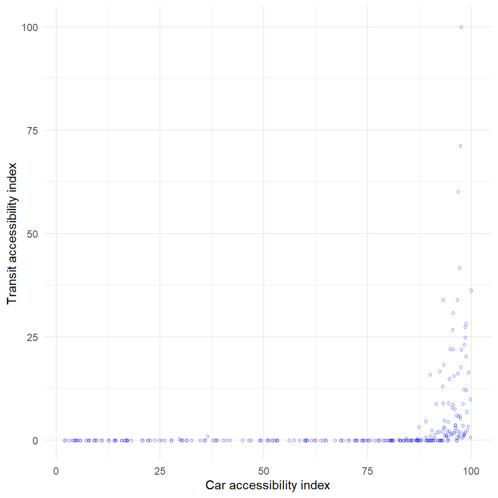

```r
ggplot(accessibility_summary) +
  geom_point(aes(x = car_index,
                 y = transit_index),
             alpha = 0.5,
             color = "blue",
             shape = "o") +
  scale_x_continuous(name = "Car accessibility index") +
  scale_y_continuous(name = "Transit accessibility index") +
  theme_minimal()
```

# Step 10: Visualize distribution of accessibility

You can create a histogram to illustrate the distribution of accessibility values for relative and/or absolute measures for cars and/or transit.

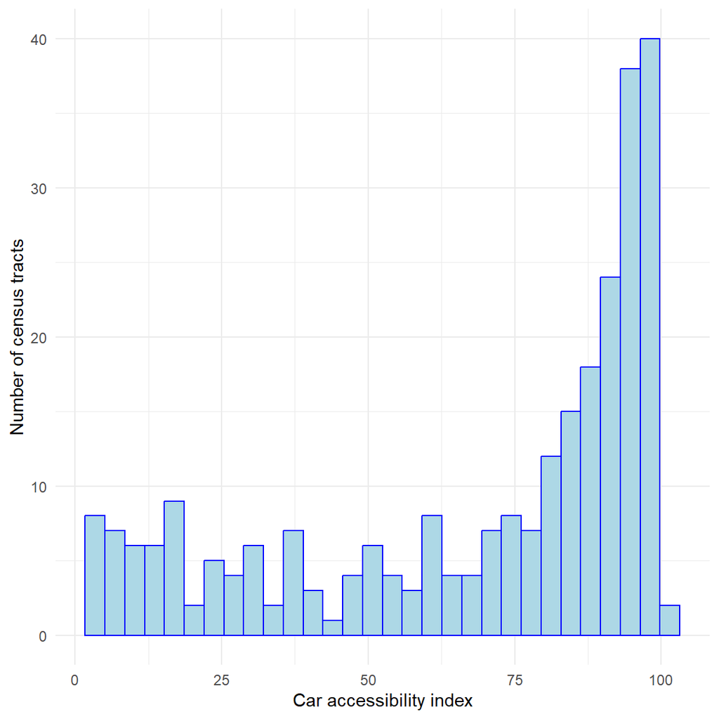

```r
ggplot(accessibility_summary) +
  geom_histogram(aes(x = car_index),
                 bins = 30,
                 color = "blue",
                 fill = "lightblue") +
  scale_x_continuous(name = "Car accessibility index") +
  scale_y_continuous(name = "Number of census tracts") +
  theme_minimal()
```

# Step 10: Visualize spatial distribution of accessibility

You can create a chloropleth map to illustrate the spatial distribution of accessibility values for relative and/or absolute measures for cars and/or transit.

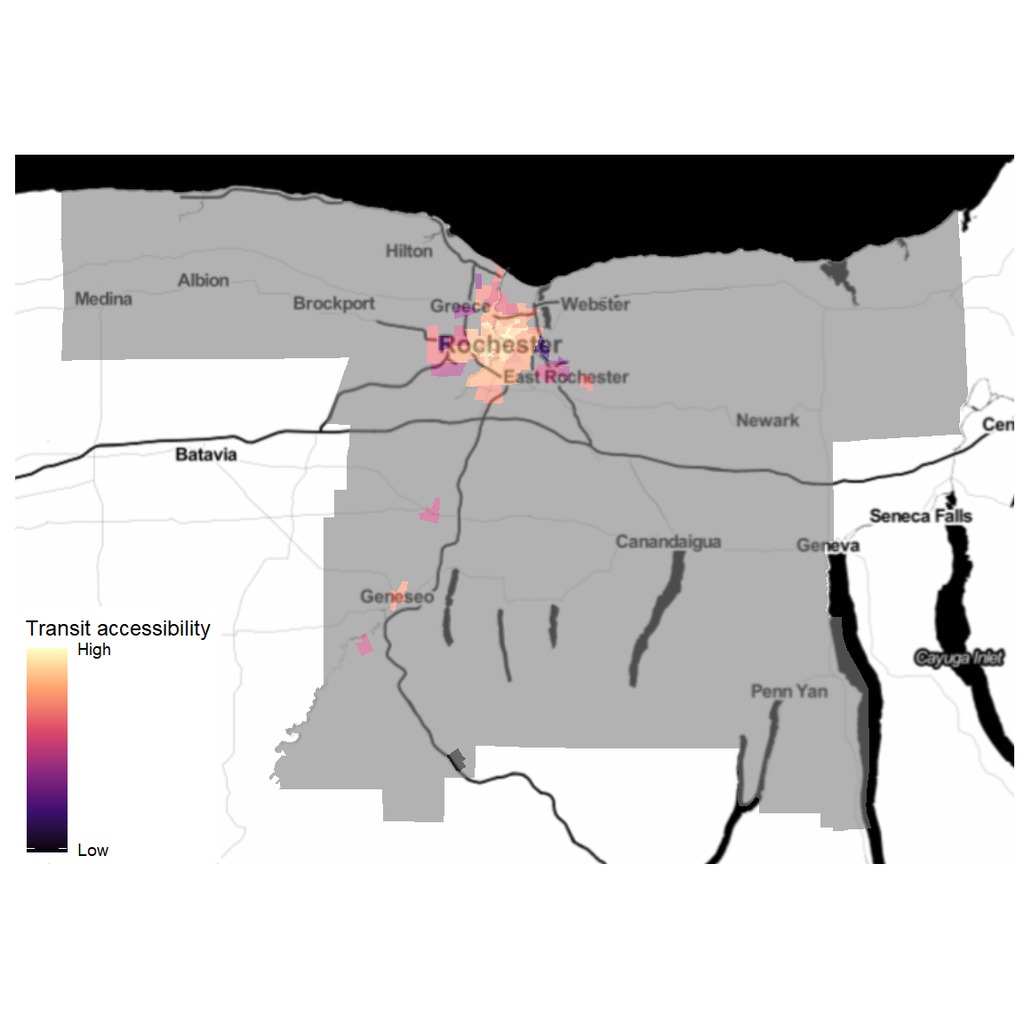

```r
accessibility_summary <- accessibility_summary %>%
  rename(GEOID = from_GEOID)

tracts <- tracts %>%
  left_join(accessibility_summary)

ggplot(tracts) +
  annotation_map_tile(type = "stamenbw",
                      zoomin = 0,
                      progress = "none") +
  geom_sf(aes(fill = transit_index),
          color = NA,
          alpha = 0.6) +
  scale_fill_viridis_c(name = "Transit accessibility",
                       trans = "log",
                       breaks = c(0.000001,100),
                       labels = c("Low",
                                  "High"),
                       option = "A") +
  theme_map()
```

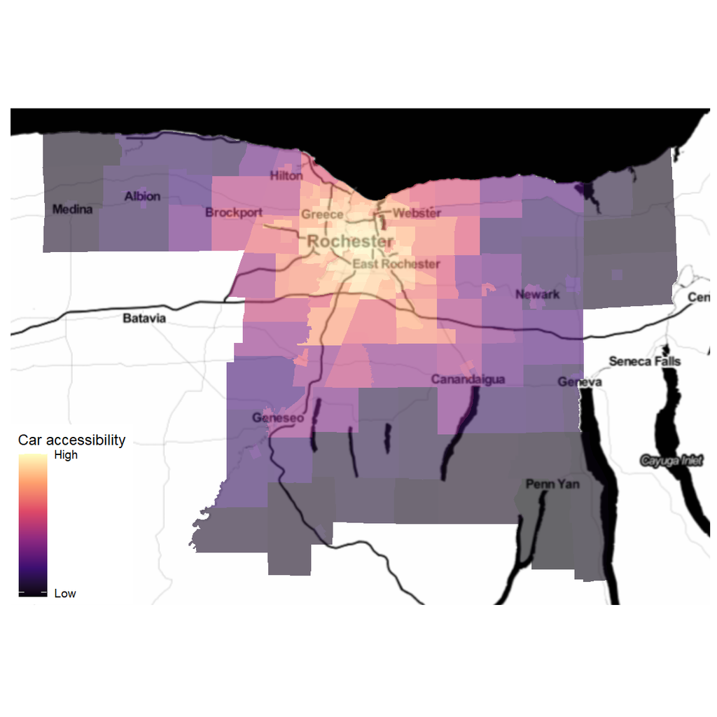

```r
ggplot(tracts) +
    annotation_map_tile(type = "stamenbw",
                      zoomin = 0,
                      progress = "none") +
  geom_sf(aes(fill = car_index),
          color = NA,
          alpha = 0.6) +
  scale_fill_viridis_c(name = "Car accessibility",
                       breaks = c(5,100),
                       labels = c("Low",
                                  "High"),
                       option = "A") +
  theme_map()
```